# QC correlation of classifier score with RNA-Seq expression

K S Gaonkar (D3B)

In this notebook we will find correlation between RNA-Seq and classifier score We will check if the values are inversely correlated as we would expect?

### Setup

```r
suppressPackageStartupMessages({
  library(ggpubr)
  library(ggthemes)
  library(tidyverse)
  library(broom)
})

# rootdir
root_dir <- rprojroot::find_root(rprojroot::has_dir(".git"))
data_dir <- file.path(root_dir, "data")
results_dir <- "results"

if ( params$base_run ==0 ){
  clinical<-read.delim(file.path(data_dir,"pbta-histologies.tsv"), stringsAsFactors = FALSE)
} else{
  clinical<-read.delim(file.path(data_dir,"pbta-histologies-base.tsv"), stringsAsFactors = FALSE)
}
```

### Classifier scores

1. Read in scores from tp53-nf1-classifier for stranded

```r
score_stranded_df <- read_tsv(file.path(results_dir, "pbta-gene-expression-rsem-fpkm-collapsed.stranded_classifier_scores.tsv")) %>%
  dplyr::select(
    "tp53_score",
    "sample_id"
  ) %>%
  as.data.frame()
```

2. Read in scores from tp53-nf1-classifier for polya

```r
score_polya_df <- read_tsv(file.path(results_dir, "pbta-gene-expression-rsem-fpkm-collapsed.polya_classifier_scores.tsv")) %>%
  dplyr::select(
    "tp53_score",
    "sample_id"
  ) %>%
  as.data.frame()
```

### Expression matrices

```r
stranded_exp_file <- file.path(data_dir,"pbta-gene-expression-rsem-fpkm-collapsed.stranded.rds")
polya_exp_file <- file.path(data_dir,"pbta-gene-expression-rsem-fpkm-collapsed.polya.rds")
```

Format expression matrices to long format

```r
expression_mat_to_long <- function(expressionFile,score_df,gene){
# load expressionMatrix RDS for expression based filtering for less than given threshold
expressionMatrix<-readRDS(expressionFile) %>%
  rownames_to_column()

# Taking snippet from @jaclyn-taroni idea used in expression based fusion call filtering

expression_long_df <- expressionMatrix %>%
  # rename rowname to GeneSymbol
  dplyr::rename(GeneSymbol=rowname) %>%
  # Get the data into long format
  reshape2::melt(variable.name = "Kids_First_Biospecimen_ID",
                 value.name = "expression_value") %>%
  dplyr::mutate(Kids_First_Biospecimen_ID= as.character(Kids_First_Biospecimen_ID)) %>%
  dplyr::filter(GeneSymbol %in% gene)

# merge score and expression file
merge_score_exp <- expression_long_df %>%
  left_join(score_df, by=c("Kids_First_Biospecimen_ID"="sample_id"))

return(merge_score_exp)
}

stranded_exp_score <- expression_mat_to_long(stranded_exp_file,score_stranded_df,"TP53")
polya_exp_score <- expression_mat_to_long(polya_exp_file,score_polya_df,"TP53")
```

### Correlation between RNA-expression and classifier sccore

Stranded

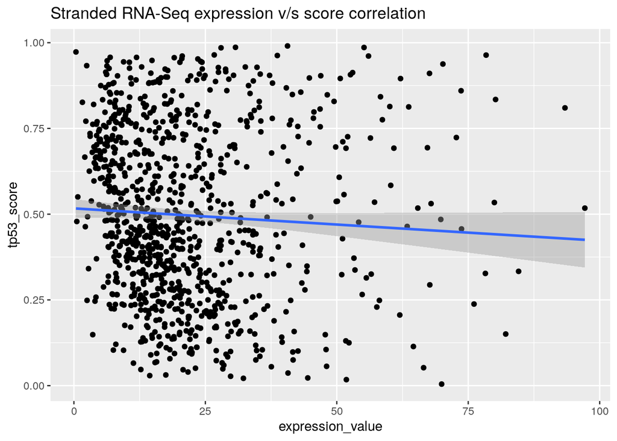

```r
ggplot(stranded_exp_score,aes(expression_value,tp53_score))+
  geom_point() +
  geom_smooth(method='lm') +
  ggtitle("Stranded RNA-Seq expression v/s score correlation")
```

Polya

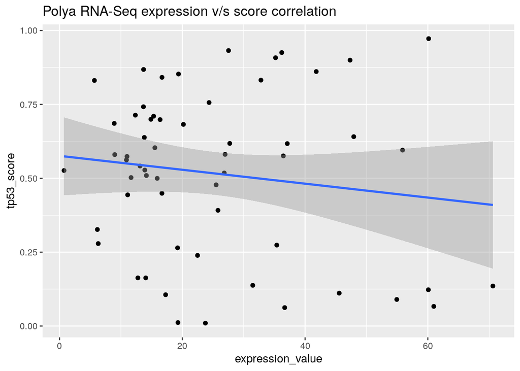

```r
ggplot(polya_exp_score,aes(expression_value,tp53_score))+
  geom_point() +
  geom_smooth(method='lm') +
  ggtitle("Polya RNA-Seq expression v/s score correlation")
```

### Corr.test

```r
tidy(cor.test(stranded_exp_score$expression_value,stranded_exp_score$tp53_score))
```

| estimate | statistic | p.value | parameter | conf.low | conf.high | method | alternative |
| --- | --- | --- | --- | --- | --- | --- | --- |
| -0.05643426 | -1.764972 | 0.0778815 | 975 | -0.1187329 | 0.006306929 | Pearson's product-moment correlation | two.sided |

```r
tidy(cor.test(polya_exp_score$expression_value,polya_exp_score$tp53_score))
```

| estimate | statistic | p.value | parameter | conf.low | conf.high | method | alternative |
| --- | --- | --- | --- | --- | --- | --- | --- |
| -0.1391526 | -1.051553 | 0.2975211 | 56 | -0.3836587 | 0.1235851 | Pearson's product-moment correlation | two.sided |

polya TP53 expression to classifier_score has a negligible negative correlation estimate -0.139 at p value 0.297

Overall distribution of expression and classifier score shows negligible correlation so we cannot directly use the expression/classifier score to infer functionality/phenotype of TP53 inactivation in samples

### Sample_id matched polya and stranded

```r
sample_id_multi_library <- clinical %>%
  filter(experimental_strategy=="RNA-Seq") %>%
  group_by(sample_id) %>%
  summarise(counts = length(unique(RNA_library)),
            RNA_library = toString(RNA_library)) %>%
  filter(counts > 1)

sample_id_multi_library
```

| sample_id | counts | RNA_library |
| --- | --- | --- |
| 7316-1455 | 2 | stranded, poly-A |
| 7316-161 | 2 | stranded, poly-A |
| 7316-255 | 2 | stranded, poly-A |
| 7316-536 | 2 | stranded, poly-A |
| 7316-85 | 2 | stranded, poly-A, stranded, stranded |
| 7316-87 | 2 | stranded, poly-A |
| A16915 | 2 | poly-A, stranded |
| A18777 | 2 | poly-A, stranded |

7316-85 has multiple stranded let’s look at the values

```r
 clinical %>%
  left_join(score_stranded_df , by=c("Kids_First_Biospecimen_ID"="sample_id")) %>%
  left_join(score_polya_df,by=c("Kids_First_Biospecimen_ID"="sample_id"),
            suffix = c("_stranded","_polya")) %>%
  filter(sample_id == "7316-85",experimental_strategy=="RNA-Seq") %>%
  select(sample_id,tp53_score_stranded,tp53_score_polya)
```

| sample_id | tp53_score_stranded | tp53_score_polya |
| --- | --- | --- |
| 7316-85 | 0.29926369 | NA |
| 7316-85 | NA | 0.06229678 |
| 7316-85 | 0.06646311 | NA |
| 7316-85 | 0.22914820 | NA |

```r
sample_id_multi_library_scores_df <- clinical %>%
  left_join(score_stranded_df , by=c("Kids_First_Biospecimen_ID"="sample_id")) %>%
  left_join(score_polya_df,by=c("Kids_First_Biospecimen_ID"="sample_id"),
            suffix = c("_stranded","_polya")) %>%
  # gather data for sample_ids which have multiple RNA_library
  filter(sample_id %in% sample_id_multi_library$sample_id,
         experimental_strategy=="RNA-Seq") %>%
  group_by(sample_id) %>%
  # because 7316-85 has multiple stranded I'm taking a mean here
  summarise( tp53_score_stranded = mean(tp53_score_stranded[!is.na(tp53_score_stranded)]),
             tp53_score_polya = mean(tp53_score_polya[!is.na(tp53_score_polya)])) %>%
  reshape2::melt()
```

Plotting the scores

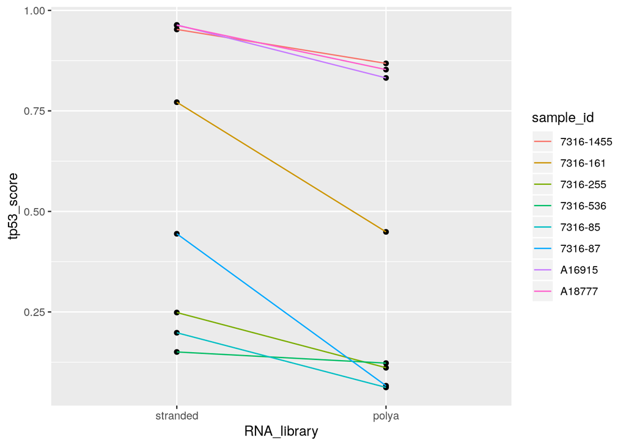

```r
ggplot(sample_id_multi_library_scores_df,
       aes(y=value,x=as.numeric(factor(sample_id_multi_library_scores_df$variable)))) +
  geom_point()+
  geom_line(aes(color=sample_id)) +
  xlim(c("stranded",
         "polya")) +
  xlab("RNA_library") + ylab("tp53_score")
```

We could consider utilizing batch correction once completed via [#919](https://github.com/AlexsLemonade/OpenPBTA-analysis/issues/919) to rerun the classifier for this dataset. We can then check whether the scores would be more similar for polyA and stranded. Instead of choosing one over the other without some additional investigation, perhaps we take an average. For the most part, while there is a bias, the scores agree and for 7316-161, although the polyA score is just under 0.5, it is still considered a loss via evidence. Once we investigate all of the evidence, we might consider a re-thresholding of the scores for what determines inactivation/oncogenic TP53 (discussed earlier).